# How to raise an issue

Help us help you

Mauro Lepore https://github.com/maurolepore  
2020-06-26

Open source packages improve thanks to people like you who [kindly contribute to open source software](https://snarky.ca/setting-expectations-for-open-source-participation/). Your contribution to the packages we build can be as simple as raising an issue. Here is how you can do just that.

Each package has a website with a link to report a bug or raise any in-scope issue (more on this below). For example, the website of the package r2dii.match lives [here](https://2degreesinvesting.github.io/r2dii.match) and looks like this:

[figure not shown]

Figure 1: The website of every package has a link to report a bug.

The link to report a bug opens a page that, like an email, has two parts:

1. A title to summarize your issue;
2. A body to detail your issue. We know you are busy; please follow our instructions carefully to avoid emails and solve the issue quickly.

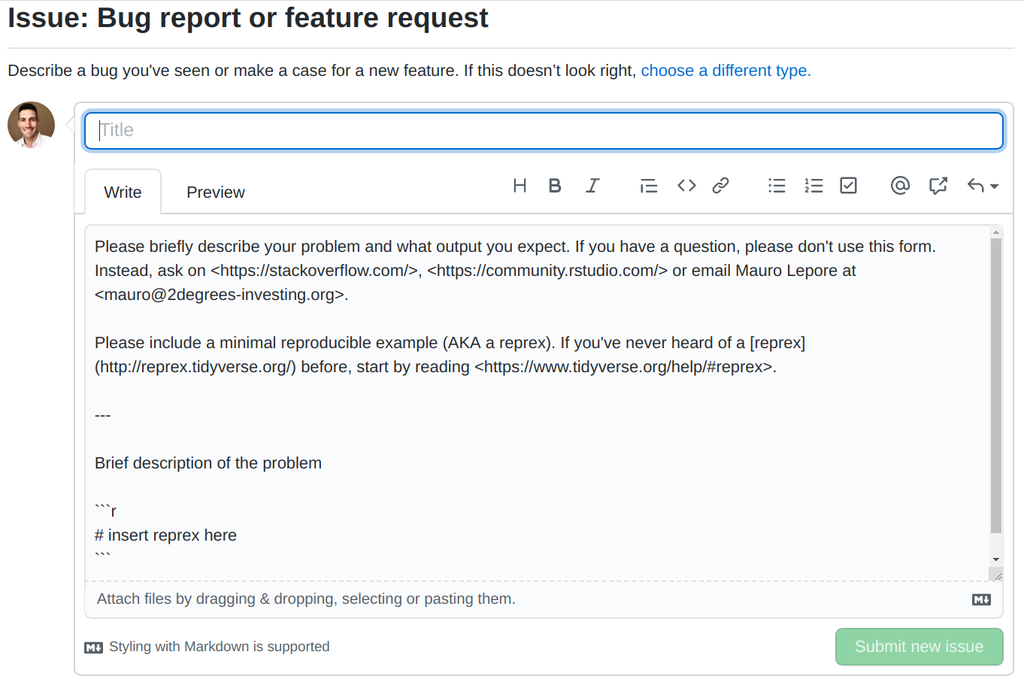

Figure 2: The web page to report a bug is like an email.

## What’s beyond our scope

Our scope is limited. We assume you are familiar with R. (To learn R see [our favorite resources](https://github.com/2DegreesInvesting/resources/issues?q=is%3Aissue+is%3Aopen+label%3Alearn+label%3Arstats).) The issues we can address are those caused specifically by the packages we build. Report everything else at https://stackoverflow.com/ or https://community.rstudio.com/.

The most common out-of-scope problems are installation errors. It’s unlikely the problem comes from our packages because [we continuously check that they install correctly – with multiple version of R, and on Windows, Linux, and several other platforms](https://cran.r-project.org/web/checks/check_results_r2dii.match.html)). What should you do then?

### A tale of two R programmers

Mike and Lucy are working together and want to use the package r2dii.match. They try to install it with `install.packages("r2dii.match")` but they get an error.

> Mike: “Bummer!”

> Lucy: “Wait; let’s read the error message carefully.”

The error message makes no sense. Mike Googles it and finds some promising results. Lucy tries a few hacks but nothing works.

> Lucy: “It’s all sooooooo confusing; but there is something about versions, right? These R geeks move fast – they pump new stuff every day!”

> Mike: “What if we ask at [RStudio community](https://community.rstudio.com/)? They seem friendly.”

> Lucy: “Yeah, those folks *are* cool. But let’s first update everything – I mean R, RStudio, and all R packages. It can’t hurt and sooner or later we’ll have to do it anyway. [Here is a nice guide](https://happygitwithr.com/install-r-rstudio.html).”

> Mike: “That’ll take a while but you are right. Let’s bite the bullet.”

After an hour or so.

> Lucy: “Okay, done! Here we go again.”

> Mike: “Fingers crossed.”

They look at each other. Then Lucy runs `install.packages("r2dii.match")`. Then it just works.

Bottom line: Get current people[^1].

[^1]: Get current, people. You don’t want to adopt new things on day one. But at some point, running old versions of software adds unnecessary difficulty. – [How to think about upgrading R and RStudio](https://happygitwithr.com/install-r-rstudio.html)